# Question 1

2023-10-17

# 1.Data Inspection and exploration:

```r
#Reading the data set diabetes.csv
datasetdiabetesoriginal= read.csv('diabetes.csv', header=TRUE)
head(datasetdiabetesoriginal)
```

```
##   Pregnancies Glucose BloodPressure SkinThickness Insulin  BMI
## 1           6     148            72            35       0 33.6
## 2           1      85            66            29       0 26.6
## 3           8     183            64             0       0 23.3
## 4           1      89            66            23      94 28.1
## 5           0     137            40            35     168 43.1
## 6           5     116            74             0       0 25.6
##   DiabetesPedigreeFunction Age Outcome
## 1                    0.627  50       1
## 2                    0.351  31       0
## 3                    0.672  32       1
## 4                    0.167  21       0
## 5                    2.288  33       1
## 6                    0.201  30       0
```

```r
sum(datasetdiabetesoriginal$Outcome==0)/nrow(datasetdiabetesoriginal)
```

```
## [1] 0.6510417
```

It is observed that the columns: Glucose, BloodPressure, SkinThichkness, Insulin and BMI, have entries with 0’s.Since values of 0 for these variables are not logical, they will become missing values (NA).

```r
#install.packages("tidyverse")
library(tidyverse)
datasetdiabetesNas <-mutate(datasetdiabetesoriginal,
                         Glucose = na_if(Glucose, 0),
                         BloodPressure = na_if(BloodPressure, 0),
                         SkinThickness = na_if(SkinThickness, 0),
                         Insulin = na_if(Insulin, 0),
                         BMI = na_if(BMI, 0))
head(datasetdiabetesNas)
```

```
##   Pregnancies Glucose BloodPressure SkinThickness Insulin  BMI
## 1           6     148            72            35      NA 33.6
## 2           1      85            66            29      NA 26.6
## 3           8     183            64            NA      NA 23.3
## 4           1      89            66            23      94 28.1
## 5           0     137            40            35     168 43.1
## 6           5     116            74            NA      NA 25.6
##   DiabetesPedigreeFunction Age Outcome
## 1                    0.627  50       1
## 2                    0.351  31       0
## 3                    0.672  32       1
## 4                    0.167  21       0
## 5                    2.288  33       1
## 6                    0.201  30       0
```

**Plots/figures with descriptive statistics**

- Histogram for Glucose and Age

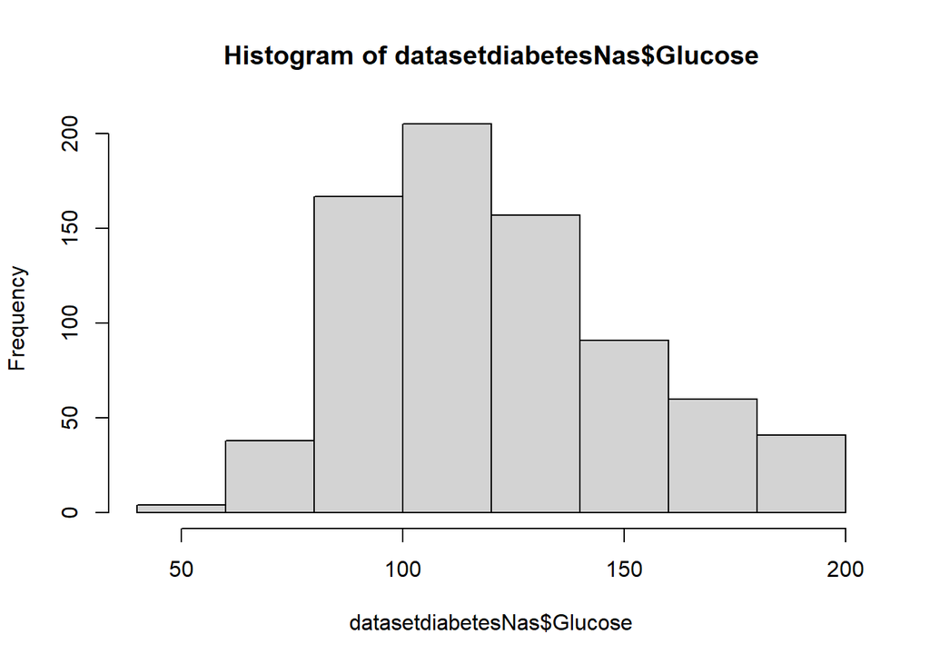

```r
hist(datasetdiabetesNas$Glucose)
```

```r
mean_glucose=mean(datasetdiabetesNas$Glucose)
sd_glucose=sd(datasetdiabetesNas$Glucose)
print(mean_glucose)
```

```
## [1] NA
```

```r
print(sd_glucose)
```

```
## [1] NA
```

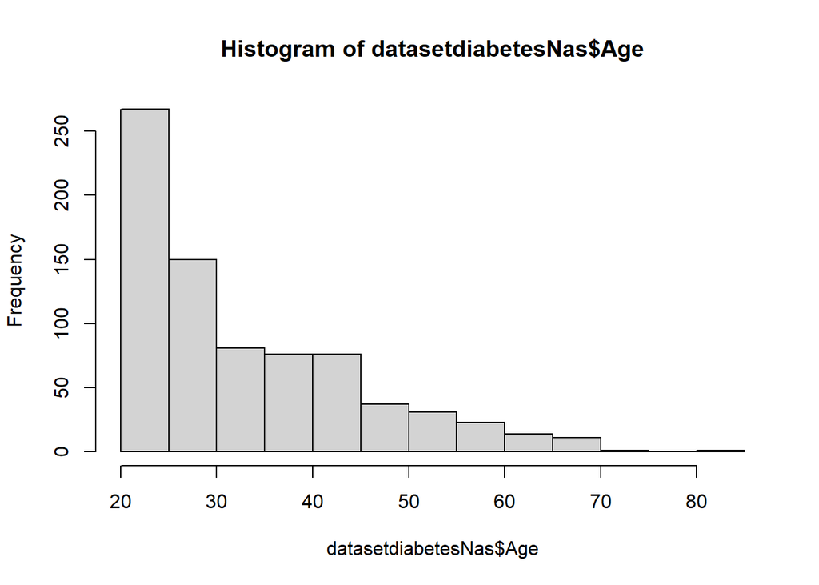

```r
hist(datasetdiabetesNas$Age)
```

It is observed that the most frequent values for the variable Glucose are between (90,140), and for the variable Age the most frequent values are between (20,30).

-Boxplot for all the variables

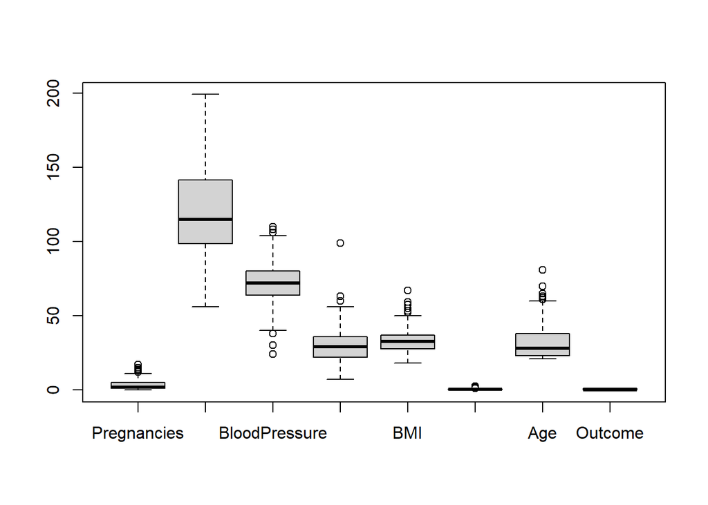

```r
dataclean=na.omit(subset(datasetdiabetesNas, select = -Insulin))
Insulin=na.omit(subset(datasetdiabetesNas, select = Insulin))
attach(dataclean)
boxplot(dataclean)
```

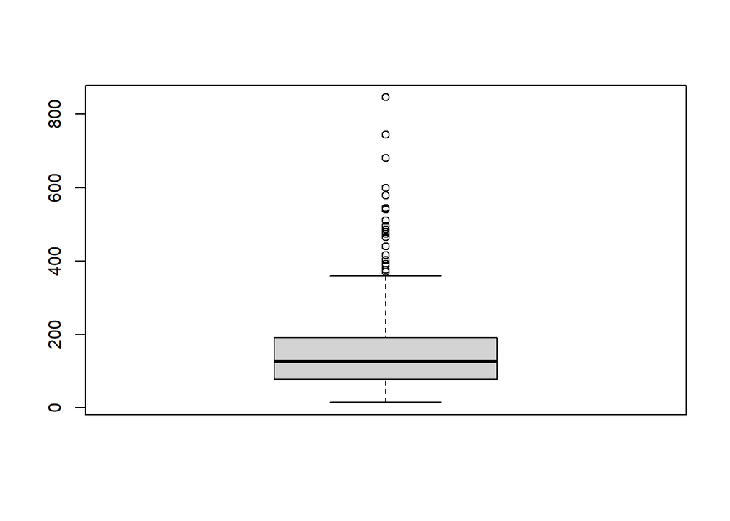

```r
boxplot(Insulin)
```

The outlines for all the variables are observed and NAs are omitted. Because the range of the insulin variable is greater than the other variables, it was graphed separately.

- Scatter Plot:

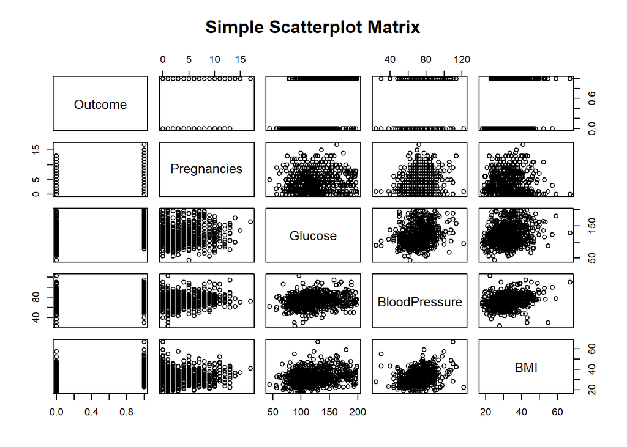

```r
pairs(~Outcome+Pregnancies+Glucose+BloodPressure+BMI,data=datasetdiabetesNas,
   main="Simple Scatterplot Matrix")
```

# 2.

In the QQ Plot, we can observe that the data deviates from normal and is right skewed:

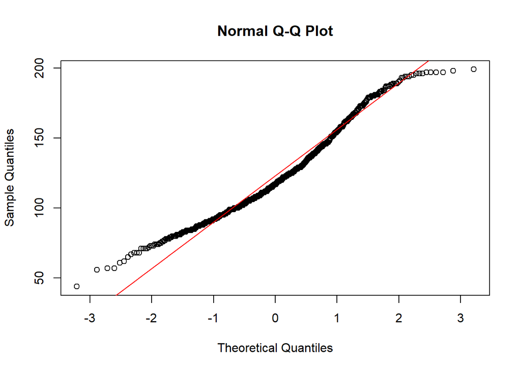

```r
##QQ Plot
glucose=na.omit(datasetdiabetesNas$Glucose)
mean_glucose=mean(glucose)
sd_glucose=sd(glucose)
qqnorm(glucose)
qqline(rnorm(100,mean_glucose,sd_glucose), col="red")
```

The Shapiro Wilk Test and the Kolmogorov-Smirnov test, return a significant p-value, then the null hypothesis is rejected and we can conclude that the Glucose variable is not normal.

```r
## Shapiro Wilks Test
shapiro.test(glucose) ##not normal
```

```
##
##  Shapiro-Wilk normality test
##
## data:  glucose
## W = 0.96964, p-value = 1.72e-11
```

```r
mean_glucose=mean(glucose)
sd_glucose=sd(glucose)
#Kolmogorov Smirnov Test
ks.test(glucose,rnorm(5000,mean_glucose,sd_glucose)) ##not normal
```

```
##
##  Asymptotic two-sample Kolmogorov-Smirnov test
##
## data:  glucose and rnorm(5000, mean_glucose, sd_glucose)
## D = 0.073831, p-value = 0.001468
## alternative hypothesis: two-sided
```

```r
ks.test(glucose, "pnorm", mean=mean_glucose, sd=sd_glucose )
```

```
##
##  Asymptotic one-sample Kolmogorov-Smirnov test
##
## data:  glucose
## D = 0.072695, p-value = 0.0006291
## alternative hypothesis: two-sided
```

# 3.

```r
data_output_1=datasetdiabetesNas[datasetdiabetesNas$Outcome==1,]$Glucose
data_output_0=datasetdiabetesNas[datasetdiabetesNas$Outcome==0,]$Glucose
t.test(data_output_1,data_output_0)
```

```
##
##  Welch Two Sample t-test
##
## data:  data_output_1 and data_output_0
## t = 14.884, df = 466.02, p-value < 2.2e-16
## alternative hypothesis: true difference in means is not equal to 0
## 95 percent confidence interval:
##  27.49380 35.85757
## sample estimates:
## mean of x mean of y
##  142.3195  110.6439
```

The P-value is significant, the confidence interval at 95% is (27.4,35.8), then the difference of the means is not equal to 0 and the t value is equal to 14.88 showing how far appart are the means from each other. In conclusion the means are different between glucose with outcome = 1 and Outcome = 0 and the difference is statistically significant.

# 4.

```r
## Convert the outcome to factor
datasetdiabetesNas$Outcome <- factor(datasetdiabetesNas$Outcome)
is.factor(datasetdiabetesNas$Outcome)
```

```
## [1] TRUE
```

```r
## Training and Testing
set.seed(21)
n=nrow(datasetdiabetesNas)
sample <- sample(c(TRUE, FALSE), n, replace=TRUE, prob=c(0.7,0.3))
train  <- datasetdiabetesNas[sample, ]
test   <- datasetdiabetesNas[!sample, ]

##probabilities of outcome in both datasets
prop.table(table(train$Outcome))
```

```
##
##         0         1
## 0.6666667 0.3333333
```

```r
prop.table(table(test$Outcome))
```

```
##
##        0        1
## 0.617284 0.382716
```

```r
# Dataset without insulin
datasetdiabetes_no_insulin <-select(datasetdiabetesNas,-Insulin)


## Training and Testing without Insulin
train_no_insulin <- datasetdiabetes_no_insulin[sample, ]
test_no_insulin <- datasetdiabetes_no_insulin[!sample, ]
```

# 5. Logistic Regresion Model

## Multiple imputation for the Diabetes Dataset

```r
#install.packages("mice")
library(mice)
```

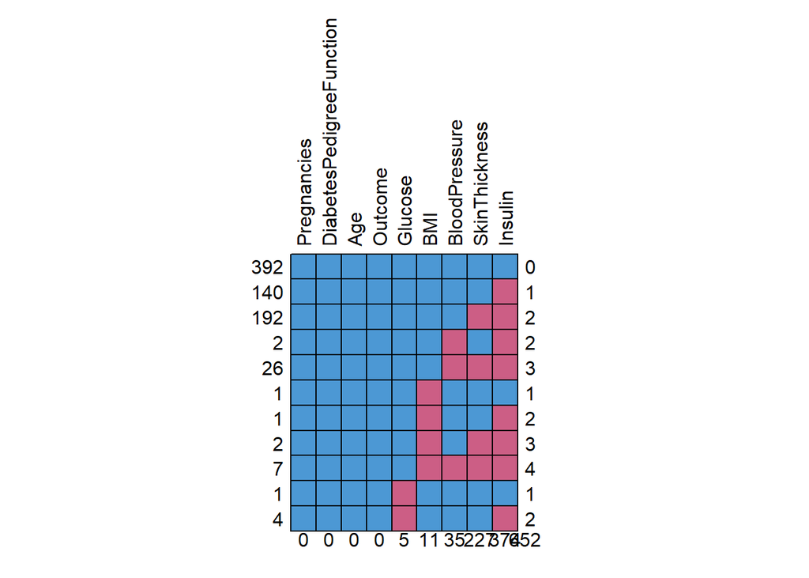

```
##     Pregnancies DiabetesPedigreeFunction Age Outcome Glucose BMI BloodPressure
## 392           1                        1   1       1       1   1             1
## 140           1                        1   1       1       1   1             1
## 192           1                        1   1       1       1   1             1
## 2             1                        1   1       1       1   1             0
## 26            1                        1   1       1       1   1             0
## 1             1                        1   1       1       1   0             1
## 1             1                        1   1       1       1   0             1
## 2             1                        1   1       1       1   0             1
## 7             1                        1   1       1       1   0             0
## 1             1                        1   1       1       0   1             1
## 4             1                        1   1       1       0   1             1
##               0                        0   0       0       5  11            35
##     SkinThickness Insulin
## 392             1       1   0
## 140             1       0   1
## 192             0       0   2
## 2               1       0   2
## 26              0       0   3
## 1               1       1   1
## 1               1       0   2
## 2               0       0   3
## 7               0       0   4
## 1               1       1   1
## 4               1       0   2
##               227     374 652
```

```r
md.pattern(datasetdiabetesNas,rotate.names=TRUE)
```

```r
nrow(datasetdiabetesNas)
```

```
## [1] 768
```

```r
summary(datasetdiabetesNas)
```

```
##   Pregnancies        Glucose      BloodPressure    SkinThickness
##  Min.   : 0.000   Min.   : 44.0   Min.   : 24.00   Min.   : 7.00
##  1st Qu.: 1.000   1st Qu.: 99.0   1st Qu.: 64.00   1st Qu.:22.00
##  Median : 3.000   Median :117.0   Median : 72.00   Median :29.00
##  Mean   : 3.845   Mean   :121.7   Mean   : 72.41   Mean   :29.15
##  3rd Qu.: 6.000   3rd Qu.:141.0   3rd Qu.: 80.00   3rd Qu.:36.00
##  Max.   :17.000   Max.   :199.0   Max.   :122.00   Max.   :99.00
##                   NA's   :5       NA's   :35       NA's   :227
##     Insulin            BMI        DiabetesPedigreeFunction      Age
##  Min.   : 14.00   Min.   :18.20   Min.   :0.0780           Min.   :21.00
##  1st Qu.: 76.25   1st Qu.:27.50   1st Qu.:0.2437           1st Qu.:24.00
##  Median :125.00   Median :32.30   Median :0.3725           Median :29.00
##  Mean   :155.55   Mean   :32.46   Mean   :0.4719           Mean   :33.24
##  3rd Qu.:190.00   3rd Qu.:36.60   3rd Qu.:0.6262           3rd Qu.:41.00
##  Max.   :846.00   Max.   :67.10   Max.   :2.4200           Max.   :81.00
##  NA's   :374      NA's   :11
##  Outcome
##  0:500
##  1:268
##
##
##
##
##
```

We can observe that 51% of rows have 0 missing values, 18.4% have 1 missing value, 25.9% have two missing values and 4% have 3 or 4 missing values.

It is also observed that the most common missing values are: 1. Insulin 2. Skin Thickness 3. Blood Pressure.

To solve the problem of missing data, I’ll use Multiple Imputation with the mice package.

```r
#Multiple imputation
m=5
diabetes.imp.data <-mice(data=train,m=m,maxit=10,print=FALSE)
diabetes.imp.data
```

```
## Class: mids
## Number of multiple imputations:  5
## Imputation methods:
##              Pregnancies                  Glucose            BloodPressure
##                       ""                    "pmm"                    "pmm"
##            SkinThickness                  Insulin                      BMI
##                    "pmm"                    "pmm"                    "pmm"
## DiabetesPedigreeFunction                      Age                  Outcome
##                       ""                       ""                       ""
## PredictorMatrix:
##               Pregnancies Glucose BloodPressure SkinThickness Insulin BMI
## Pregnancies             0       1             1             1       1   1
## Glucose                 1       0             1             1       1   1
## BloodPressure           1       1             0             1       1   1
## SkinThickness           1       1             1             0       1   1
## Insulin                 1       1             1             1       0   1
## BMI                     1       1             1             1       1   0
##               DiabetesPedigreeFunction Age Outcome
## Pregnancies                          1   1       1
## Glucose                              1   1       1
## BloodPressure                        1   1       1
## SkinThickness                        1   1       1
## Insulin                              1   1       1
## BMI                                  1   1       1
```

```r
#plot(diabetes.imp.data)
#stripplot(diabetes.imp.data)
```

The method used for all the variables was pmm, predictive mean matching.

## Logistic Regression Model

```r
## Ordinary Logistic regression with missing data

model_out <- glm(Outcome ~ ., data = train, family = binomial() )
summary(model_out)
```

```
##
## Call:
## glm(formula = Outcome ~ ., family = binomial(), data = train)
##
## Coefficients:
##                            Estimate Std. Error z value Pr(>|z|)
## (Intercept)              -9.7723144  1.4523891  -6.728 1.71e-11 ***
## Pregnancies               0.0141226  0.0739732   0.191  0.84859
## Glucose                   0.0408724  0.0070718   5.780 7.49e-09 ***
## BloodPressure            -0.0104526  0.0138985  -0.752  0.45201
## SkinThickness             0.0176740  0.0209982   0.842  0.39996
## Insulin                  -0.0008474  0.0015001  -0.565  0.57214
## BMI                       0.0542818  0.0339766   1.598  0.11013
## DiabetesPedigreeFunction  0.6933936  0.5436851   1.275  0.20218
## Age                       0.0612131  0.0234404   2.611  0.00902 **
## ---
## Signif. codes:  0 '***' 0.001 '**' 0.01 '*' 0.05 '.' 0.1 ' ' 1
##
## (Dispersion parameter for binomial family taken to be 1)
##
##     Null deviance: 347.54  on 272  degrees of freedom
## Residual deviance: 232.01  on 264  degrees of freedom
##   (252 observations deleted due to missingness)
## AIC: 250.01
##
## Number of Fisher Scoring iterations: 5
```

```r
## Ordinary Logistic regression without Insulin
model_out_no_insulin <- glm(Outcome ~ ., data = train_no_insulin, family = binomial() )
summary(model_out_no_insulin)
```

```
##
## Call:
## glm(formula = Outcome ~ ., family = binomial(), data = train_no_insulin)
##
## Coefficients:
##                           Estimate Std. Error z value Pr(>|z|)
## (Intercept)              -9.211504   1.170602  -7.869 3.57e-15 ***
## Pregnancies               0.080962   0.057653   1.404   0.1602
## Glucose                   0.037250   0.005098   7.306 2.75e-13 ***
## BloodPressure            -0.020781   0.012132  -1.713   0.0867 .
## SkinThickness             0.009927   0.018117   0.548   0.5837
## BMI                       0.076829   0.029499   2.604   0.0092 **
## DiabetesPedigreeFunction  1.086194   0.470849   2.307   0.0211 *
## Age                       0.047688   0.017522   2.722   0.0065 **
## ---
## Signif. codes:  0 '***' 0.001 '**' 0.01 '*' 0.05 '.' 0.1 ' ' 1
##
## (Dispersion parameter for binomial family taken to be 1)
##
##     Null deviance: 473.12  on 374  degrees of freedom
## Residual deviance: 317.01  on 367  degrees of freedom
##   (150 observations deleted due to missingness)
## AIC: 333.01
##
## Number of Fisher Scoring iterations: 5
```

```r
## Logistic Regression with multiple imputation

models <- lapply(1:m, function(i) {
  model <- glm(Outcome ~ ., data = complete(diabetes.imp.data, i), family = "binomial")
  return(model)
})

pooled_model <- pool(models)
summary(pooled_model)
```

```
##                       term      estimate   std.error  statistic        df
## 1              (Intercept) -9.1543668146 1.037998902 -8.8192452 352.57464
## 2              Pregnancies  0.1253654019 0.042542323  2.9468396 477.98570
## 3                  Glucose  0.0381349827 0.005536734  6.8876318 119.51405
## 4            BloodPressure -0.0111268182 0.010262699 -1.0842000 486.93335
## 5            SkinThickness  0.0037547189 0.017664404  0.2125585  42.14727
## 6                  Insulin -0.0007588956 0.001438466 -0.5275730  24.49300
## 7                      BMI  0.0922064519 0.027317256  3.3753922 130.18166
## 8 DiabetesPedigreeFunction  0.7711316967 0.376289769  2.0493029 508.27392
## 9                      Age  0.0169225306 0.011906417  1.4212950 446.95173
##        p.value
## 1 5.396548e-17
## 2 3.367284e-03
## 3 2.829052e-10
## 4 2.788127e-01
## 5 8.326961e-01
## 6 6.025427e-01
## 7 9.718508e-04
## 8 4.094529e-02
## 9 1.559283e-01
```

```r
AIC <- lapply(1:m,function(i) {
  aic_i <-models[[i]]$aic
  return(aic_i)
})
print(AIC)
```

```
## [[1]]
## [1] 494.5971
##
## [[2]]
## [1] 491.4894
##
## [[3]]
## [1] 494.8755
##
## [[4]]
## [1] 490.7071
##
## [[5]]
## [1] 492.4589
```

```r
##Size of data without NAs
dimensions_without_Nas=dim(na.omit(datasetdiabetesNas))
dimenstios_without_Insulin=dim(na.omit(datasetdiabetes_no_insulin))
print(dimensions_without_Nas)
```

```
## [1] 392   9
```

```r
print(dimenstios_without_Insulin)
```

```
## [1] 532   8
```

- In the first model 252 rows were deleted due NAs, although this model is the one with the lowest AIC, because it has less data is less reliable that the model without the variable Insulin. The low AIC could indicate that the model is overfiting the data.
- In the model without the variable insulin the AIC is 333, the model lays in the middle of the other two models. -In the model with multiple imputation due to the large number of outliers and missing data, the AIC is higher that indicates that worse regression results were generated (even for larger numbers of multiple imputations like m=20).

# 6. Predictions, Results and analysis

## Model Without Insulin:

```r
#install.packages("caret")
library(caret)
#Accuracy for training data
train_no_insulin <-na.omit(train_no_insulin)
predicted_probs <- predict(model_out_no_insulin, type="response")
predicted_class <- ifelse(predicted_probs > 0.5, 1, 0)
confusionMatrix(as.factor(predicted_class), as.factor(train_no_insulin$Outcome))
```

```
## Confusion Matrix and Statistics
##
##           Reference
## Prediction   0   1
##          0 228  50
##          1  25  72
##
##                Accuracy : 0.8
##                  95% CI : (0.7559, 0.8393)
##     No Information Rate : 0.6747
##     P-Value [Acc > NIR] : 4.642e-08
##
##                   Kappa : 0.5189
##
##  Mcnemar's Test P-Value : 0.005584
##
##             Sensitivity : 0.9012
##             Specificity : 0.5902
##          Pos Pred Value : 0.8201
##          Neg Pred Value : 0.7423
##              Prevalence : 0.6747
##          Detection Rate : 0.6080
##    Detection Prevalence : 0.7413
##       Balanced Accuracy : 0.7457
##
##        'Positive' Class : 0
##
```

```r
#Accuracy for testing data
test_no_insulin <-na.omit(test_no_insulin)
predicted_probs <- predict(model_out_no_insulin, newdata=test_no_insulin, type="response")
predicted_class <- ifelse(predicted_probs > 0.5, 1, 0)
confusionMatrix(as.factor(predicted_class), as.factor(test_no_insulin$Outcome))
```

```
## Confusion Matrix and Statistics
##
##           Reference
## Prediction  0  1
##          0 87 26
##          1 15 29
##
##                Accuracy : 0.7389
##                  95% CI : (0.6628, 0.8056)
##     No Information Rate : 0.6497
##     P-Value [Acc > NIR] : 0.01072
##
##                   Kappa : 0.3986
##
##  Mcnemar's Test P-Value : 0.11835
##
##             Sensitivity : 0.8529
##             Specificity : 0.5273
##          Pos Pred Value : 0.7699
##          Neg Pred Value : 0.6591
##              Prevalence : 0.6497
##          Detection Rate : 0.5541
##    Detection Prevalence : 0.7197
##       Balanced Accuracy : 0.6901
##
##        'Positive' Class : 0
##
```

The accuracy of the model for the training dataset is 80% and for the testing dataset is 73.8%, in both cases it is observed that the quantity for false negatives is larger than false positives, i.e. several people with diabetes were mistakenly classified as non-diabetics by the model.